# Exercises STAT340 - Mixed Effects Models

You will need these libraries and datasets for these exercises:

```r
library(BIAS.data)
library(nlme)
library(lme4)
library(ggplot2)
data(rats)
data(Orthodont)
data(cbpp)
```

# 1 Ex-1: Random Intercept Model — `rats` data

The `rats` dataset from the `BIAS.data` package contains measurements of `Glycogen` content in rat livers. Each rat (`Rat`) was measured across three different liver sections (`Treatment`).

1. Visualise the `Glycogen` content by `Rat` using a boxplot. What does the plot tell you about the variance *between* rats versus the variance *within* rats?

**Solution**

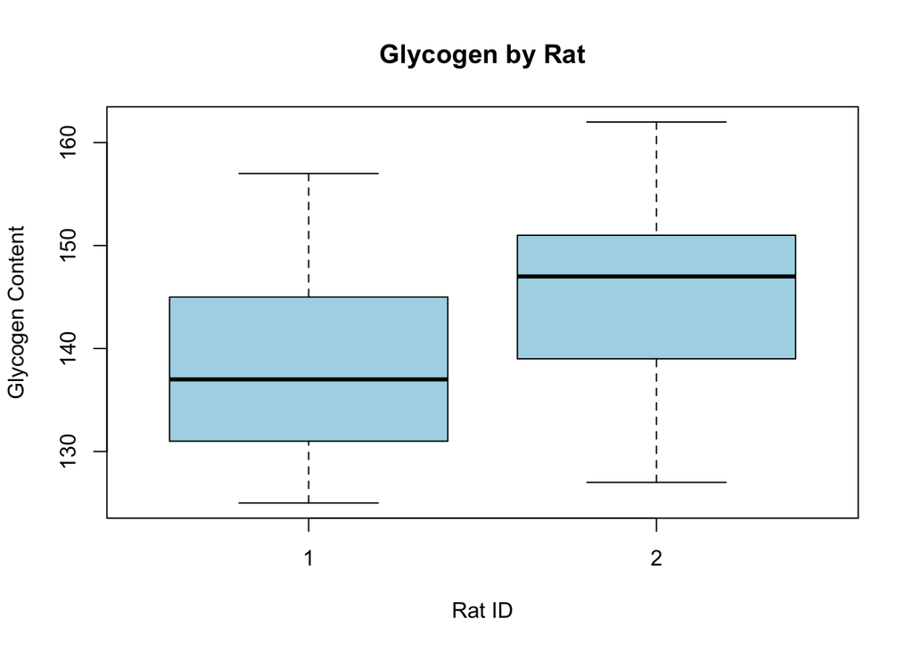

```r
boxplot(Glycogen ~ Rat, data = rats, col = "lightblue",
        ylab = "Glycogen Content", xlab = "Rat ID",
        main = "Glycogen by Rat")
```

2. Write down the mathematical formulation of a **random intercept model** for the `rats` data, explaining clearly what each term represents.

**Solution**

Let $y_{ij}$ be the Glycogen measurement for the $j$-th section of the $i$-th rat. The random intercept model is:

$$y_{ij} = \beta_0 + b_i +
\epsilon_{ij}$$

where:

- $\beta_0$ is the global mean glycogen content (fixed intercept),
- $b_i \sim N(0, \sigma^2_b)$ is the rat-specific random deviation from the global mean,
- $\epsilon_{ij} \sim N(0, \sigma^2)$ is the residual measurement error.

The $b_i$ and $\epsilon_{ij}$ are assumed independent.

3. Fit the random intercept model using `lme()` from the `nlme` package, with `Glycogen` as the response and `Rat` as the random effect grouping. Report the estimated variance components $\widehat\sigma_b$ and $\widehat\sigma$.

**Solution**

```r
rat_model <- lme(fixed = Glycogen ~ 1,
                 random = ~ 1 | Rat,
                 data = rats)
summary(rat_model)
```

```
## Linear mixed-effects model fit by REML
##   Data: rats
##        AIC      BIC    logLik
##   266.2975 270.9635 -130.1487
##
## Random effects:
##  Formula: ~1 | Rat
##         (Intercept) Residual
## StdDev:    4.266496  9.26216
##
## Fixed effects:  Glycogen ~ 1
##                Value Std.Error DF  t-value p-value
## (Intercept) 142.2222  3.388876 34 41.96737       0
##
## Standardized Within-Group Residuals:
##        Min         Q1        Med         Q3        Max
## -1.9334507 -0.6648481 -0.1658917  0.6068381  1.8854657
##
## Number of Observations: 36
## Number of Groups: 2
```

From the output, the estimated standard deviations are approximately:

- Between-rat (random intercept): $\widehat\sigma_b \approx 4.27$
- Residual (within-rat): $\widehat\sigma \approx 9.26$
4. Calculate the **Intraclass Correlation Coefficient (ICC)** using the variance components from part c. Interpret what the ICC means in this context.

**Solution**

The ICC formula is:

$$\text{ICC} =
\frac{\sigma^2_b}{\sigma^2_b + \sigma^2}$$

Using the estimates above:

$$\sigma^2_b = 4.27^2 \approx 18.23, \quad
\sigma^2 = 9.26^2 \approx 85.75$$

$$\text{ICC} = \frac{18.23}{18.23 + 85.75}
\approx 0.175$$

```r
vc <- as.numeric(VarCorr(rat_model)[, "Variance"])
sigma2_b <- vc[1]
sigma2   <- vc[2]
icc <- sigma2_b / (sigma2_b + sigma2)
round(icc, 3)
```

```
## [1] 0.175
```

**Interpretation:** About 17.5% of the total variation in Glycogen content is explained purely by which rat the measurement came from. In other words, two measurements from the **same** rat are expected to correlate at $r \approx 0.175$, even before we account for treatment.

5. Why would it be **wrong** to use a standard linear model (ignoring `Rat`) here? What problems would arise?

**Solution**

**Solution**

The extended nested model is:

$$y_{ijk} = \beta_0 + b_i + c_{j(i)} +
\epsilon_{ijk}$$

where:

- $b_i \sim N(0, \sigma^2_b)$: random intercept for rat $i$,
- $c_{j(i)} \sim N(0, \sigma^2_c)$: random intercept for liver section $j$ **nested within** rat $i$ (each rat has its own section-level deviations),
- $\epsilon_{ijk} \sim N(0, \sigma^2)$: residual error.

In `nlme`, nesting is expressed with the `/` operator in the `random` argument:

```r
rat_nested <- lme(fixed = Glycogen ~ 1,
                  random = ~ 1 | Rat/Treatment,
                  data = rats)
summary(rat_nested)
```

```
## Linear mixed-effects model fit by REML
##   Data: rats
##        AIC      BIC    logLik
##   246.1212 252.3426 -119.0606
##
## Random effects:
##  Formula: ~1 | Rat
##         (Intercept)
## StdDev: 0.002645158
##
##  Formula: ~1 | Treatment %in% Rat
##         (Intercept) Residual
## StdDev:    8.549312 5.700877
##
## Fixed effects:  Glycogen ~ 1
##                Value Std.Error DF  t-value p-value
## (Intercept) 142.2222   3.61726 30 39.31766       0
##
## Standardized Within-Group Residuals:
##         Min          Q1         Med          Q3         Max
## -1.73265128 -0.59926763  0.04268264  0.54769958  2.09321107
##
## Number of Observations: 36
## Number of Groups:
##                Rat Treatment %in% Rat
##                  2                  6
```

The output now shows **three** variance components:

- Between-rat variance ($\sigma^2_b$): how much rats differ on average.
- Between-section-within-rat variance ($\sigma^2_c$): how much the three liver sections differ systematically within the same rat.
- Residual variance ($\sigma^2$): pure measurement noise.

# 2 Ex-2: Random Intercept + Random Slope — `fertilizer` data

The `fertilizer` dataset from `BIAS.data` tracks the root length of individual plants over several weeks. Plants are assigned to either a `fertilizer` or `control` treatment group.

1. Plot the individual plant trajectories (root length over weeks) coloured by treatment group. Do plants appear to grow at different rates (slopes), or do they just start at different lengths (intercepts)?

**Solution**

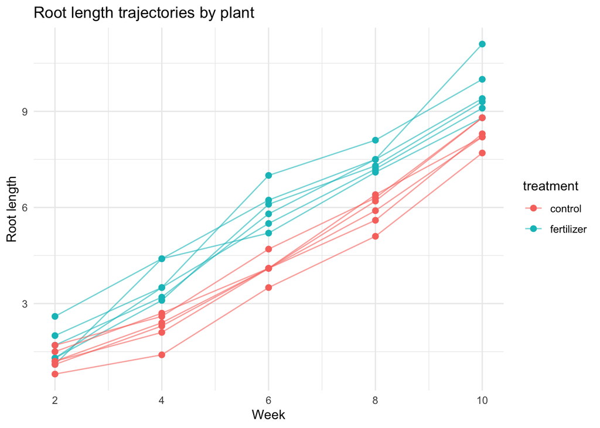

```r
data(fertilizer)
ggplot(fertilizer, aes(x = week, y = root, color = treatment)) +
  geom_line(aes(group = plant), alpha = 0.6) +
  geom_point(size = 2) +
  theme_minimal() +
  labs(title = "Root length trajectories by plant",
       x = "Week", y = "Root length")
```

The plot reveals that plants differ in both their **starting length** (intercepts vary) and their **rate of growth** (slopes vary). This motivates a model with both random intercepts and random slopes.

2. Write down the mathematical model that allows both the intercept and the slope over `week` to vary randomly by `plant`. Explain each component.

**Solution**

Let $y_{ij}$ be the root length of the $i$-th plant at week $x_{ij}$:

$$y_{ij} = (\beta_0 + b_{0i}) + (\beta_1 +
b_{1i})\,x_{ij} + \epsilon_{ij}$$

where:

- $\beta_0$: global average starting length (fixed intercept),
- $\beta_1$: global average growth rate per week (fixed slope),
- $b_{0i}$: plant-specific deviation from the average intercept,
- $b_{1i}$: plant-specific deviation from the average slope,
- $\epsilon_{ij} \sim N(0, \sigma^2)$: residual error.

The random effects $(b_{0i}, b_{1i})$ are assumed to follow a bivariate normal distribution.

3. Fit the random intercept + random slope model in R using `lme()`. Include `treatment` as a fixed effect and allow both the intercept and `week` slope to vary randomly by `plant`. Report the estimated fixed effects and interpret the `treatmentfertilizer` coefficient.

**Solution**

```r
data(fertilizer)
res1 <- lme(fixed = root ~ treatment,
            random = ~ week | plant,
            data = fertilizer)
round(summary(res1)$tTable, 4)
```

```
##                      Value Std.Error DF t-value p-value
## (Intercept)         1.7603    0.1438 48 12.2384   0e+00
## treatmentfertilizer 1.0394    0.2034 10  5.1096   5e-04
```

**Interpretation:**

- `(Intercept)` ≈ baseline root length for the control group.
- `treatmentfertilizer` ≈ 1.04: On average, plants receiving fertilizer are **1.04 units longer** than control plants. This effect is highly significant ($p = 0.0005$).
- Note that `week` is modelled as a **random slope**, so there is no single fixed-effect estimate for it; each plant gets its own slope.
4. Examine the residual diagnostic plots (fitted vs residuals and QQ plot of standardised residuals). Do the model assumptions appear to be satisfied?

**Solution**

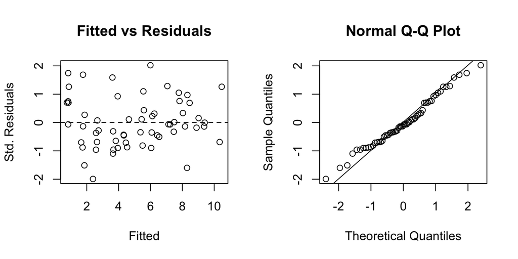

```r
par(mfrow = c(1, 2))
plot(fitted(res1), resid(res1, type = "p"),
     main = "Fitted vs Residuals", ylab = "Std. Residuals", xlab = "Fitted")
abline(h = 0, lty = 2)
qqnorm(resid(res1, type = "p"))
qqline(resid(res1, type = "p"))
```

```r
par(mfrow = c(1, 1))
```

The residuals appear randomly scattered around zero with no clear pattern, and the QQ plot follows the diagonal line well. The model assumptions of homoscedasticity and normality seem reasonably satisfied.

5. Calculate the ICC **at week 0** using the random effects standard deviations from the model summary. Interpret the result.

**Solution**

From the `summary(res1)` output:

- $\widehat\sigma_{b0} \approx 2.86$ (random intercept SD)
- $\widehat\sigma \approx 0.50$ (residual SD)

At week 0, the between-plant variance equals only the intercept variance:

$$\text{ICC}_{week=0} =
\frac{\sigma^2_{b0}}{\sigma^2_{b0} + \sigma^2} = \frac{2.86^2}{2.86^2 +
0.50^2} = \frac{8.18}{8.18 + 0.25} \approx 0.97$$

```r
sigma_b0 <- as.numeric(VarCorr(res1)["(Intercept)", "StdDev"])
sigma_res <- as.numeric(VarCorr(res1)["Residual",   "StdDev"])
icc_week0 <- sigma_b0^2 / (sigma_b0^2 + sigma_res^2)
round(icc_week0, 3)
```

```
## [1] 0.971
```

**Interpretation:** At the start of the experiment (week 0), almost **97% of the variation** in root length is due to which plant we are measuring — i.e., the plant’s individual genetics/seed quality. As time progresses and the random slopes diverge, this proportion changes.

6. Using the model from part c. (`res1`, with `treatment` as a fixed effect and `week` as a random slope by `plant`), produce predictions at two levels:
   1. **Population-level** (`level = 0`): the average expected root length for a **control** plant and a **fertilizer** plant over weeks 1–5, using only the fixed effects.
   2. **Individual-level** (`level = 1`): the predicted root length for two specific plants from the dataset over the same weeks, using their estimated random effects.

   Comment on the difference between the two types of predictions.

**Solution**

We refit `res1` as in part c. and use `predict()` with `level = 0` (population) and `level = 1` (individual).

```r
data(fertilizer)
res1 <- lme(fixed = root ~ treatment,
            random = ~ week | plant,
            data = fertilizer)

# (i) Population-level: same prediction for any plant of that treatment
new_pop <- data.frame(
  plant     = rep(unique(fertilizer$plant)[1], 10), # id needed but ignored
  week      = rep(1:5, 2),
  treatment = rep(c("control", "fertilizer"), each = 5)
)
new_pop$pred_pop <- predict(res1, newdata = new_pop, level = 0)
print(new_pop)
```

```
##    plant week  treatment pred_pop
## 1    ID1    1    control 1.760327
## 2    ID1    2    control 1.760327
## 3    ID1    3    control 1.760327
## 4    ID1    4    control 1.760327
## 5    ID1    5    control 1.760327
## 6    ID1    1 fertilizer 2.799709
## 7    ID1    2 fertilizer 2.799709
## 8    ID1    3 fertilizer 2.799709
## 9    ID1    4 fertilizer 2.799709
## 10   ID1    5 fertilizer 2.799709
```

```r
# (ii) Individual-level: predictions for two specific plants
plants_used <- unique(fertilizer$plant)[c(1, 5)]
new_ind <- data.frame(
  plant     = rep(plants_used, each = 5),
  week      = rep(1:5, 2),
  treatment = rep(
    fertilizer$treatment[match(plants_used, fertilizer$plant)],
    each = 5
  )
)
new_ind$pred_ind <- predict(res1, newdata = new_ind, level = 1)
print(new_ind)
```

```
##    plant week  treatment  pred_ind
## 1    ID1    1 fertilizer 0.5623431
## 2    ID1    2 fertilizer 1.6489835
## 3    ID1    3 fertilizer 2.7356239
## 4    ID1    4 fertilizer 3.8222644
## 5    ID1    5 fertilizer 4.9089048
## 6    ID5    1 fertilizer 0.9709248
## 7    ID5    2 fertilizer 1.8509450
## 8    ID5    3 fertilizer 2.7309653
## 9    ID5    4 fertilizer 3.6109855
## 10   ID5    5 fertilizer 4.4910057
```

**Key difference:**

- **Level 0 (population)** uses only the fixed effect $\widehat\beta_0 + \widehat\beta_\text{treatment}$. The prediction is identical for every plant of that treatment group — it is the model’s best guess for a **new, unseen** plant.
- **Level 1 (individual)** adds the plant’s estimated random intercept $\widehat b_{0i}$ and random slope $\widehat b_{1i}$, giving the best prediction *for that specific plant* based on its observed data. Individual predictions vary across plants and are closer to the actual observed values.

# 3 Ex-3: Hierarchical Nested Design — `Orthodont` data

The `Orthodont` dataset (available via `nlme`) tracks the pituitary `distance` (mm) in children at ages 8, 10, 12, and 14. Children (`Subject`) are nested within `Sex`.

1. Produce a spaghetti plot of `distance` over `age`, coloured by `Sex`, with one line per subject. Describe the key features you observe.

**Solution**

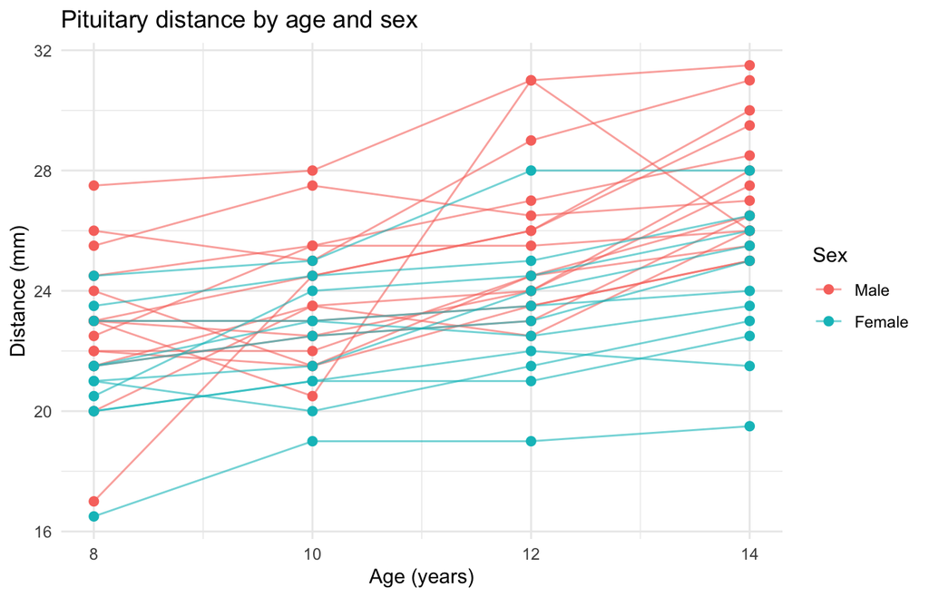

```r
data(Orthodont)
ggplot(Orthodont, aes(x = age, y = distance, color = Sex)) +
  geom_line(aes(group = Subject), alpha = 0.6) +
  geom_point(size = 2) +
  theme_minimal() +
  labs(title = "Pituitary distance by age and sex",
       x = "Age (years)", y = "Distance (mm)")
```

Key observations:

- Both boys and girls show **increasing distance** with age.
- Males tend to have **higher** baseline distances than females.
- There is substantial **between-child variability** in both starting distance and rate of growth.
2. Fit a **random intercept** model with `age` and `Sex` as fixed effects and `Subject` as the random grouping factor. Write the mathematical model first, then fit it in R using `lme()`.

**Solution**

Let $y_{ijk}$ be the distance for subject $i$ of sex $k$ at age $x_{ijk}$:

$$y_{ijk} = \beta_0 + \beta_1
\text{Age}_{ijk} + \beta_2 \text{Sex}_k + b_{i(k)} +
\epsilon_{ijk}$$

where $b_{i(k)} \sim N(0, \sigma^2_b)$ is the random intercept for subject $i$ nested within sex $k$.

```r
res3 <- lme(fixed = distance ~ age + Sex,
            random = ~ 1 | Subject,
            data = Orthodont)
summary(res3)
```

```
## Linear mixed-effects model fit by REML
##   Data: Orthodont
##        AIC      BIC    logLik
##   447.5125 460.7823 -218.7563
##
## Random effects:
##  Formula: ~1 | Subject
##         (Intercept) Residual
## StdDev:    1.807425 1.431592
##
## Fixed effects:  distance ~ age + Sex
##                 Value Std.Error DF   t-value p-value
## (Intercept) 17.706713 0.8339225 80 21.233044  0.0000
## age          0.660185 0.0616059 80 10.716263  0.0000
## SexFemale   -2.321023 0.7614168 25 -3.048294  0.0054
##  Correlation:
##           (Intr) age
## age       -0.813
## SexFemale -0.372  0.000
##
## Standardized Within-Group Residuals:
##         Min          Q1         Med          Q3         Max
## -3.74889609 -0.55034466 -0.02516628  0.45341781  3.65746539
##
## Number of Observations: 108
## Number of Groups: 27
```

3. Interpret the fixed effect coefficients for `age` and `SexFemale`. Are both significant?

**Solution**

Because this is a **random intercept** model, the growth rate of 0.66 mm/year is assumed to be the **same for all children** — only their baseline distances differ.

4. Calculate the ICC for the `Orthodont` random intercept model and interpret it.

**Solution**

```r
vc3 <- as.numeric(VarCorr(res3)[, "Variance"])
sigma2_b3  <- vc3[1]
sigma2_res3 <- vc3[2]
icc3 <- sigma2_b3 / (sigma2_b3 + sigma2_res3)
round(icc3, 3)
```

```
## [1] 0.614
```

Using $\widehat\sigma_b \approx 1.807$ and $\widehat\sigma \approx 1.432$:

$$\text{ICC} = \frac{1.807^2}{1.807^2 +
1.432^2} = \frac{3.265}{3.265 + 2.051} \approx 0.614$$

**Interpretation:** About **61.4%** of the remaining variation in pituitary distance (after accounting for age and sex) is due to permanent biological differences between individual children. The four measurements within the same child are highly correlated.

5. Now extend the model by adding a **random slope** for `age` (in addition to the random intercept) by `Subject`. Fit this extended model and compare the random effects standard deviations to the random-intercept-only model. What does adding a random slope capture?

**Solution**

```r
res4 <- lme(fixed = distance ~ age + Sex,
            random = ~ age | Subject,
            data = Orthodont)
summary(res4)
```

```
## Linear mixed-effects model fit by REML
##   Data: Orthodont
##        AIC      BIC    logLik
##   449.2339 467.8116 -217.6169
##
## Random effects:
##  Formula: ~age | Subject
##  Structure: General positive-definite, Log-Cholesky parametrization
##             StdDev    Corr
## (Intercept) 2.7970227 (Intr)
## age         0.2264274 -0.766
## Residual    1.3100398
##
## Fixed effects:  distance ~ age + Sex
##                 Value Std.Error DF   t-value p-value
## (Intercept) 17.635200 0.8862449 80 19.898788   0.000
## age          0.660185 0.0712532 80  9.265338   0.000
## SexFemale   -2.145492 0.7574539 25 -2.832504   0.009
##  Correlation:
##           (Intr) age
## age       -0.838
## SexFemale -0.348  0.000
##
## Standardized Within-Group Residuals:
##         Min          Q1         Med          Q3         Max
## -3.08141704 -0.45675583  0.01552695  0.44704158  3.89437694
##
## Number of Observations: 108
## Number of Groups: 27
```

The extended model now estimates:

- A standard deviation for the **random intercept** (between-child baseline differences).
- A standard deviation for the **random slope on age** (between-child differences in growth rate).

Adding a random slope for `age` allows each child to have their own individual growth trajectory — some children grow faster, some slower — rather than forcing everyone to grow at the global average rate of ~0.66 mm/year.

6. Compare the random-intercept-only model (`res3`) and the random-intercept + random-slope model (`res4`) using **AIC** and **BIC**. Refit both models with **ML** (not REML) before comparing, since the two models differ only in their random effects structure. Which model does each criterion prefer, and does the conclusion differ between AIC and BIC? Explain why BIC tends to be more conservative (prefers simpler models) than AIC.

**Solution**

When comparing models with **different random effects**, we must use ML (not REML), because REML likelihoods are not comparable across models with different random-effects structures.

```r
res3_ml <- lme(fixed = distance ~ age + Sex,
               random = ~ 1 | Subject,
               data = Orthodont,
               method = "ML")
res4_ml <- lme(fixed = distance ~ age + Sex,
               random = ~ age | Subject,
               data = Orthodont,
               method = "ML",
               control = lmeControl(maxIter = 200, msMaxIter = 200))

data.frame(
  Model = c("Random intercept only", "Random intercept + slope"),
  df    = c(attr(logLik(res3_ml), "df"), attr(logLik(res4_ml), "df")),
  AIC   = round(c(AIC(res3_ml), AIC(res4_ml)), 2),
  BIC   = round(c(BIC(res3_ml), BIC(res4_ml)), 2)
)
```

```
##                      Model df    AIC    BIC
## 1    Random intercept only  5 444.86 458.27
## 2 Random intercept + slope  7 446.84 465.61
```

**Conclusion:**

Simpler model is preferred in our cases w.r.t. to both criteria.

# 4 Ex-4: Generalized Linear Mixed Model — `cbpp` data

The `cbpp` dataset (from `lme4`) records cases of Contagious Bovine Pleuropneumonia (CBPP) across several herds of cattle over four time periods.

Variables:

- `incidence`: Number of sick cows in the herd (successes).
- `size`: Total number of cows in the herd (trials).
- `period`: Time period (1–4), treated as a fixed effect.
- `herd`: The specific herd (random effect — some herds may be in more disease-prone environments).
1. Why is it important to include `herd` as a **random** rather than a **fixed** effect in this model?

**Solution**

The herds in the study are a **random sample** from a larger population of herds. We are not interested in the specific disease rates of these exact 15 herds, but in the general herd-to-herd variation. Treating `herd` as a random effect allows us to:

1. Properly account for the correlation among measurements within the same herd across periods.
2. Estimate the **variance component** due to herd-level factors (environment, management, genetics).
3. Generalise conclusions beyond the specific herds observed.

If we treated `herd` as fixed, we would consume many degrees of freedom and only draw conclusions about those specific 15 herds.

2. Write the GLMM formulation for this model. What link function is used, and why?

**Solution**

Let $y_{ij}$ be the incidence count in herd $i$ during period $j$, with $n_{ij}$ total cows. We model:

$$y_{ij} \sim \text{Binomial}(n_{ij},\,
\pi_{ij})$$

$$\text{logit}(\pi_{ij}) = \beta_0 +
\beta_1 \text{Period}_{ij} + b_i, \quad b_i \sim N(0,
\sigma^2_b)$$

The **logit link** is used because the response is a proportion (disease incidence rate), and the logit maps probabilities in $(0,1)$ to the whole real line, making it compatible with the linear predictor.

3. Fit the GLMM using `glmer()` from `lme4` with `period` as a fixed effect and a random intercept for `herd`. Use `family = binomial`. Report the fixed effect estimates.

**Solution**

```r
glmm_mod <- glmer(cbind(incidence, size - incidence) ~
                    period + (1 | herd),
                  family = binomial(link = "logit"),
                  data = cbpp)
round(summary(glmm_mod)$coefficients, 4)
```

```
##             Estimate Std. Error z value Pr(>|z|)
## (Intercept)  -1.3983     0.2312 -6.0478   0.0000
## period2      -0.9919     0.3032 -3.2721   0.0011
## period3      -1.1282     0.3228 -3.4948   0.0005
## period4      -1.5797     0.4220 -3.7430   0.0002
```

The estimated fixed effects are on the **log-odds scale**:

- `(Intercept)`: The log-odds of disease incidence in the reference period (period 1) for an average herd.
- `period2`, `period3`, `period4`: The change in log-odds relative to period 1. All are negative, indicating the disease rate is **decreasing over the four periods**.
4. Extract the estimated random intercept standard deviation $\widehat\sigma_b$ from the fitted GLMM. What does it tell us about herd-to-herd variability in disease risk?

**Solution**

```r
sigma_b_glmm <- as.data.frame(VarCorr(glmm_mod))$sdcor[1]
round(sigma_b_glmm, 3)
```

```
## [1] 0.642
```

The estimated $\widehat\sigma_b$ gives the standard deviation of the herd-level random intercepts **on the log-odds scale**. A value $\widehat\sigma_b \approx 0.6$–$1.0$ (typical for these data) means that herds differ noticeably in their baseline disease susceptibility. Herds with positive $b_i$ have higher log-odds (higher incidence), while those with negative $b_i$ are more resistant. Ignoring this variation would lead to incorrect (too narrow) confidence intervals for the period effects.

6. Suppose we **did not know the herd sizes** (`size`) and only observed the raw incidence counts. Fit a **Poisson GLMM** with `period` as a fixed effect and a random intercept for `herd`. Explain when a Poisson model is an appropriate alternative to the Binomial model for count data, and what the key difference in interpretation is.

**Solution**

```r
glmm_pois <- glmer(incidence ~ period + (1 | herd),
                   family = poisson(link = "log"),
                   data = cbpp)
round(summary(glmm_pois)$coefficients, 4)
```

```
##             Estimate Std. Error z value Pr(>|z|)
## (Intercept)   1.2768     0.1908  6.6929        0
## period2      -1.1249     0.2748 -4.0938        0
## period3      -1.3191     0.2963 -4.4526        0
## period4      -1.9450     0.3971 -4.8984        0
```

**When is the Poisson model appropriate?**

The Binomial model requires knowing the **total number of trials** (`size`) so it can model the *proportion* that are successes. The Poisson model is appropriate when:

1. We only observe **raw counts** of events without knowing the denominator (total at risk).
2. The counts arise from a process where events are rare and approximately independent (e.g., number of disease cases per time period in an unlimited population).
3. The expected count is well below the maximum possible count, so the Binomial approximates a Poisson.

**Difference in interpretation:**

- **Binomial GLMM**: Fixed effects are on the **log-odds** scale; we model the *probability* of an individual cow being sick given herd size.
- **Poisson GLMM**: Fixed effects are on the **log-count** scale; we model the *expected number* of cases per period, ignoring herd size. A one-unit change in a predictor multiplies the expected count by $e^{\widehat\beta}$.

In practice, because we *do* know `size` here, the Binomial model is more appropriate — it uses all available information. The Poisson model in this context discards the denominator and effectively assumes all herds have the same exposure, which is not true.

# 5 Ex-5: Temporal Autocorrelation — `Orthodont` with CAR(1)

Instead of treating repeated measurements on children as exchangeable (standard random intercept), we can explicitly model the fact that measurements closer in time may be more correlated than distant ones.

1. Fit a model with fixed effects `age` and `Sex`, a random intercept for `Subject`, **and** a continuous-time AR(1) (`corCAR1`) correlation structure across `age`. Report the estimated autocorrelation parameter $\Phi$.

**Solution**

```r
model_car1 <- lme(fixed = distance ~ age + Sex,
                  random = ~ 1 | Subject,
                  correlation = corCAR1(form = ~ 1 + age | Subject),
                  data = Orthodont)
summary(model_car1)$modelStruct$corStruct
```

```
## Correlation structure of class corCAR1 representing
##       Phi
## 0.2418536
```

2. *(Optional — hard)* What does a CAR(1) correlation structure assume about how the correlation between two measurements changes as the time gap between them increases?

**Solution**

A continuous-time AR(1) (CAR1) structure assumes that the correlation between two measurements on the same subject at times $t_1$ and $t_2$ decays **exponentially** with the time difference:

$$\text{Corr}(y_{t_1}, y_{t_2}) =
\Phi^{|t_1 - t_2|}$$

So:

- Measurements 2 years apart (e.g., age 8 and 10) correlate as $\Phi^2$.
- Measurements 4 years apart (e.g., age 8 and 12) correlate as $\Phi^4$.
- Measurements 6 years apart (e.g., age 8 and 14) correlate as $\Phi^6$.

As $|t_1 - t_2| \to \infty$, the correlation $\to 0$. This is more realistic than assuming all repeated measurements correlate equally (compound symmetry / random intercept only).

3. Why is it important to use **REML** (the default in `lme()`) rather than standard **ML** when estimating variance components in linear mixed models?

**Solution**

When we estimate variance components using standard Maximum Likelihood (ML), the estimator is **biased downward** — it is too small. This happens because ML does not account for the degrees of freedom used up by estimating the fixed effects.

**REML (Restricted Maximum Likelihood)** corrects for this by first “removing” the fixed effects from the likelihood (working with the residuals rather than the raw data), and then estimating the variance components. The analogy is the divisor $n-1$ in the sample variance formula: we adjust for having estimated the mean.

Key rules:

- Use **REML** (default) when your goal is accurate variance component estimates.
- Use **ML** when you need to compare models with **different fixed effects** via likelihood ratio tests, since REML likelihoods are not comparable across different fixed-effect structures.